# Clustering analysis and statistics

Håkon Kaspersen

29.08.2019

```r
library(dplyr)
library(tidyr)
library(ggplot2)
library(ggtree)
library(ape)
library(tibble)
library(vegan)
library(distanceR)
library(impoRt)
library(readxl)
library(readr)
library(iteRate)
library(treeio)
library(adephylo)
library(phangorn)
library(RColorBrewer)
library(kableExtra)
```

```r
# Vector of excluded samples
ex_samples <- c(
  "2016-17-565-1-S",
  "2016-02-428-2-S",
  "2016-02-486-2-S",
  "2016-02-732-2-S",
  "2014-01-1741-1-S"
  )

# Collapses data frame to unique lines while ignoring NA's
func_paste <- function(x) paste(unique(x[!is.na(x)]), collapse = ", ")

"%not_in%" <- Negate("%in%")


# Isolate data
id_data <- read.table("../data/id.txt",
                      sep = "\t",
                      header = TRUE,
                      stringsAsFactors = F)

isolate_data <- read.table("../data/isolate_data.txt",
                           sep = "\t",
                           header = T,
                           stringsAsFactors = F) %>%
  filter(id %not_in% ex_samples)

mlst_data <- read.table("../data/mlst_results.txt",
                        sep = "\t",
                        header = TRUE,
                        stringsAsFactors = F)
```

# 1 Patristic distances

Patristic distances were calculated from the core gene alignment SNP tree. The labelled clades are the groups further investigated.

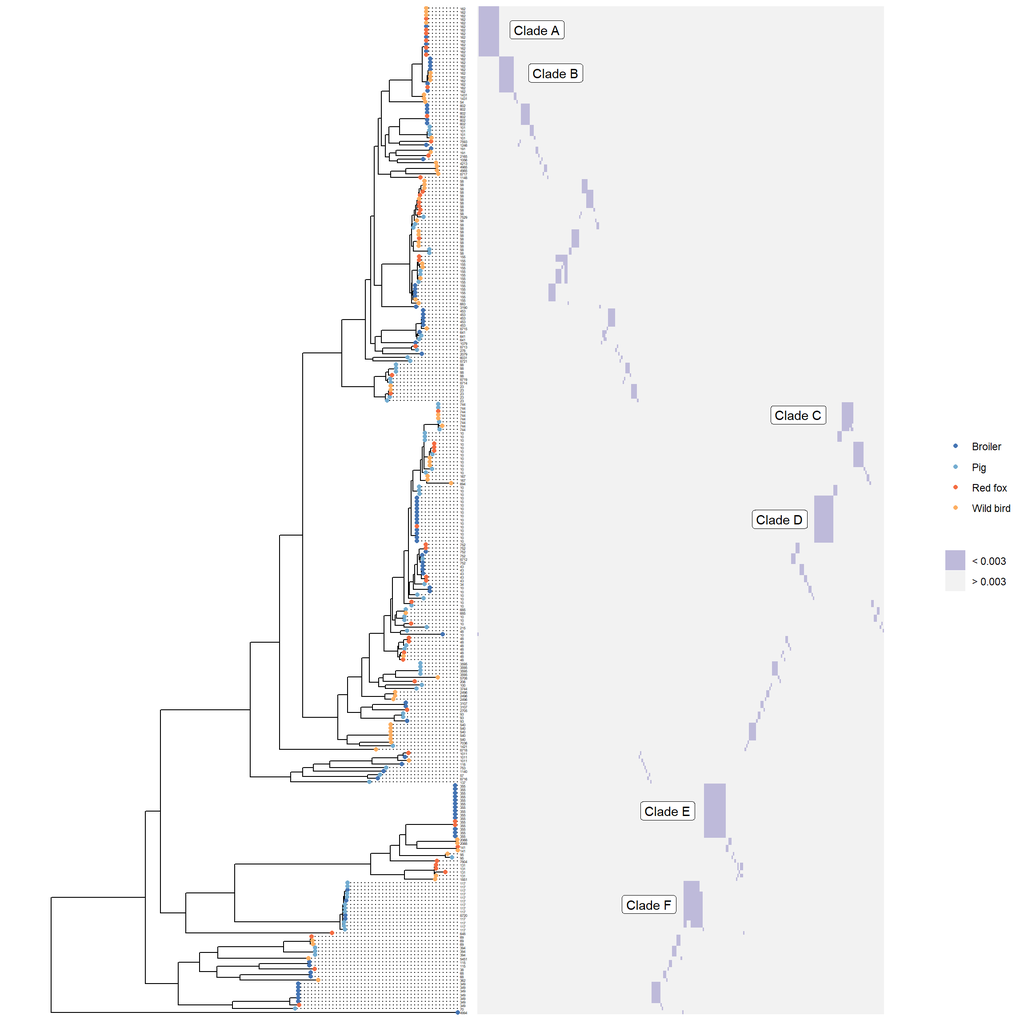

```r
location_data <- read_excel("../data/st_location_data.xlsx") %>%
  select(id, Kommune, Fylke) %>%
  mutate(fyl_id = group_indices(., Fylke),
         kom_id = group_indices(., Kommune)) %>%
  mutate(Location = paste(fyl_id, kom_id, sep = "-")) %>%
  select(id, Location)

tree_metadata <- read.table("../data/chewbbaca/complete_results/tree_metadata.txt",
                            sep = "\t",
                            header = TRUE) %>%
  left_join(location_data, by = "id") %>%
  mutate(Year = substr(id, 1, 4)) %>%
  dplyr::rename("Species" = species)

iqtree <- read.iqtree("../data/Phylogeny/Roary/iqtree_roary.contree")
iqtree_clean <- fix_tip_labels(iqtree, id_data, "_pilon_spades.fasta", tree_type = "treedata")

pat_dist <- as.matrix(distTips(iqtree_clean@phylo, method = "patristic"))

iqtree_clean@phylo <- midpoint(iqtree_clean@phylo, labels = "support")

pat_dist_id <- as.data.frame(pat_dist) %>%
  rownames_to_column("isol1") %>%
  gather(isol2, value, -isol1) %>%
  filter(isol1 != isol2) %>%
  left_join(tree_metadata, by = c("isol1" = "id")) %>%
  rename("ST1" = ST,
         "Species1" = Species,
         "Location1" = Location,
         "Year1" = Year) %>%
  left_join(tree_metadata, by = c("isol2" = "id")) %>%
  rename("ST2" = ST,
         "Species2" = Species,
         "Location2" = Location,
         "Year2" = Year) %>%
  filter(value < 0.005) %>%
  mutate(selection = case_when(Species1 == Species2 & Location1 != Location2 ~ "ss",
                               Species1 != Species2 & is.na(Location1) == FALSE ~ "as")) %>%
  filter(selection %in% c("ss", "as"))

tree_metadata <- read.table("../data/chewbbaca/complete_results/tree_metadata.txt",
                            sep = "\t",
                            header = TRUE) %>%
  left_join(location_data, by = "id") %>%
  mutate(Year = substr(id, 1, 4)) %>%
  dplyr::rename("Species" = species) %>%
  mutate(ST_new = ifelse(ST %in% pat_dist_id$ST1, ST, "Other"))

pat_dist_bin <- as.data.frame(ifelse(pat_dist < 0.003, "< 0.003", "> 0.003"))

col_palette <- c("< 0.003" = "#bebada",
                 "> 0.003" = "grey95")

palette <- c("Broiler" = "#4575b4",
             "Pig" = "#74add1",
             "Red fox" = "#f46d43",
             "Wild bird" = "#fdae61")

p <- ggtree(iqtree_clean) %<+% tree_metadata +
  geom_tiplab(aes(label = ST),
              size = 1,
              align = TRUE) +
  scale_color_manual(values = palette) +
  geom_tippoint(aes(color = Species))

gheatmap(p,
         pat_dist_bin,
         color = NULL,
         offset = 0.01,
         colnames = FALSE) +
  scale_fill_manual(values = col_palette) +
  annotate("label", x = 0.26, y = 274, label = "Clade A") +
  annotate("label", x = 0.27, y = 262, label = "Clade B") +
  annotate("label", x = 0.40, y = 167, label = "Clade C") +
  annotate("label", x = 0.39, y = 138, label = "Clade D") +
  annotate("label", x = 0.33, y = 57, label = "Clade E") +
  annotate("label", x = 0.32, y = 31, label = "Clade F")
```

# 2 SNP distance statistics on clades of interest

The table presents the summary statistics on the minimum SNP distance to the closest isolate per clade of interest.

```r
dist_data <- get_data("../data/Phylogeny/STs",
                      "gubbins_snp_dists.tab",
                      recursive = TRUE,
                      df = FALSE)

names(dist_data) <- c("Clade D", "Clade F", "Clade A", "Clade B", "Clade E", "Clade C")

dist_clean <- lapply(dist_data, function(x){
  x %>%
    dplyr::rename("isol1" = `snp-dists 0.6.3`) %>%
    gather(isol2, value, -isol1) %>%
    filter(isol1 != isol2) %>%
    group_by(isol2) %>%
    mutate(min_val = min(value))
})

summary_list <- lapply(dist_clean, function(x) round(summary(x$min_val),0)) %>%
  bind_rows()

summary_list$Type <- c("Min","1st.Q","Median","Mean","3rd.Q","Max")

summary_list %>%
  select(Type,
         `Clade A`,
         `Clade B`,
         `Clade C`,
         `Clade D`,
         `Clade E`,
         `Clade F`) %>%
  kable() %>%
  kable_styling(bootstrap_options = c("striped", "hover"))
```

| Type | Clade A | Clade B | Clade C | Clade D | Clade E | Clade F |
| --- | --- | --- | --- | --- | --- | --- |
| Min | 4 | 8 | 50 | 7 | 3 | 3 |
| 1st.Q | 9 | 12 | 56 | 10 | 6 | 8 |
| Median | 16 | 13 | 62 | 11 | 10 | 37 |
| Mean | 20 | 19 | 59 | 17 | 10 | 112 |
| 3rd.Q | 28 | 17 | 63 | 24 | 13 | 127 |
| Max | 66 | 65 | 66 | 31 | 21 | 374 |

# 3 Maximum likelihood trees on selected clades

The table presents the evolutionary model predicted by IQTree, and the percent shared genome calculated by ParSNP for each selected clade

| Clade | Evolutionary model | Shared genome |
| --- | --- | --- |
| A | K2P+ASC+R2 | 88.4% |
| C | K3P+ASC | 88.4% |
| D | K2P+ASC+R2 | 87.2% |
| E | K3P+ASC | 90.2% |

**Subclade trees**

The values on each node is the UF Bootstrap values calculated by IQTree. The tip point shape represent the animal species of origin, and the color the year of isolation. The tip labels represent the location of the isolate; the first number represent the county, and the second number the municipality.

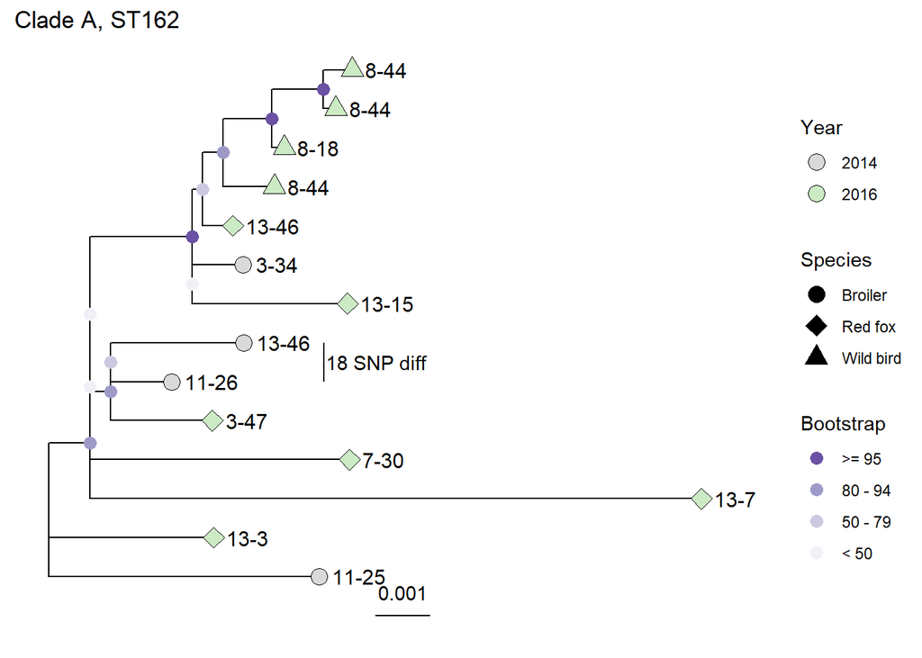

```r
# Import isolate information and tree metadata
location_data <- read_excel("../data/st_location_data.xlsx") %>%
  select(id, Kommune, Fylke) %>%
  mutate(fyl_id = group_indices(., Fylke),
         kom_id = group_indices(., Kommune)) %>%
  mutate(Location = paste(fyl_id, kom_id, sep = "-")) %>%
  select(id, Location)

# Import trees
ST10_raw <- read.iqtree("../data/Phylogeny/STs/ST10/iqtree/iqtree.contree")
ST162_A_raw <- read.iqtree("../data/Phylogeny/STs/ST162_A/iqtree/iqtree.contree")
ST355_raw <- read.iqtree("../data/Phylogeny/STs/ST355/iqtree/iqtree.contree")
ST744_raw <- read.iqtree("../data/Phylogeny/STs/ST744/iqtree/iqtree.contree")

raw_trees <- list(ST10_raw,
                  ST162_A_raw,
                  ST355_raw,
                  ST744_raw)

names(raw_trees) <- c("Clade D","Clade A","Clade E","Clade C")

# Clean tree tip labels
clean_trees <- lapply(
  raw_trees,
  function(x) fix_tip_labels(
    x,
    id_data,
    "_pilon_spades.fasta",
    tree_type = "treedata"
    )
  )

clean_trees <- lapply(clean_trees,
                      function(x) {
                        x@data$Bootstrap <- factor(
                          case_when(
                            x@data$UFboot >= 95 ~ ">= 95",
                            x@data$UFboot < 95 &
                              x@data$UFboot >= 80 ~ "80 - 94",
                            x@data$UFboot < 80 &
                              x@data$UFboot >= 50 ~ "50 - 79",
                            x@data$UFboot < 50 ~ "< 50"
                          ),
                          ordered = TRUE,
                          levels = c(">= 95",
                                     "80 - 94",
                                     "50 - 79",
                                     "< 50")
                        )
                        return(x)
                      })

# Specify color and shape palettes
palette_shape <- c(
  "Broiler" = 21,
  "Pig" = 22,
  "Red fox" = 23,
  "Wild bird" = 24
)

palette_color <- brewer.pal(11, "Set3")

year_val <- c(
  "2006",
  "2007",
  "2008",
  "2009",
  "2010",
  "2011",
  "2012",
  "2013",
  "2014",
  "2015",
  "2016")

names(palette_color) <- year_val

boot_palette <- c(">= 95" = "#6a51a3",
              "80 - 94" = "#9e9ac8",
              "50 - 79" = "#cbc9e2",
              "< 50" = "#f2f0f7")

# Generate trees
annotate_tree(
  clean_trees$`Clade A`,
  tree_metadata,
  layout = "rectangular",
  tree_type = "treedata",
  line_width = 0.5,
  label_variable = "Location",
  color_variable = "Year",
  shape_variable = "Species",
  bootstrap_var = "Bootstrap",
  clade_label_node = 26,
  clade_label = "18 SNP diff",
  cladelabel_offset = 0.0014,
  bootstrap_lab = FALSE,
  tippoint_size = 4,
  label_offset = 0.00018,
  shape_palette = palette_shape,
  color_palette = palette_color,
  node_palette = boot_palette
) +
  xlim(0, 0.0125) +
  ggtitle("Clade A, ST162") +
  scale_color_manual(values = boot_palette,
                     breaks = c(">= 95",
                                "80 - 94",
                                "50 - 79",
                                "< 50"))
```

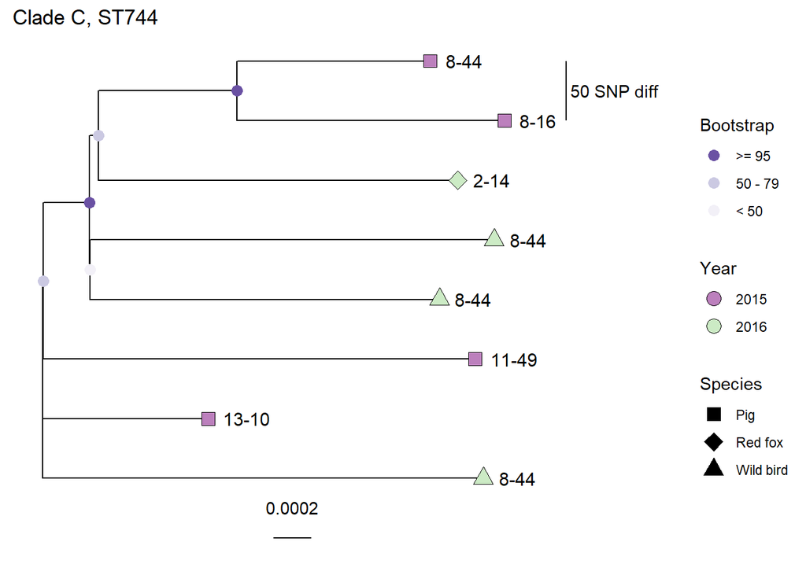

```r
annotate_tree(
  clean_trees$`Clade C`,
  tree_metadata,
  layout = "rectangular",
  tree_type = "treedata",
  line_width = 0.5,
  label_variable = "Location",
  color_variable = "Year",
  shape_variable = "Species",
  bootstrap_var = "Bootstrap",
  clade_label_node = 14,
  clade_label = "50 SNP diff",
  cladelabel_offset = 0.00028,
  bootstrap_lab = FALSE,
  tippoint_size = 4,
  label_offset = 0.00007,
  shape_palette = palette_shape,
  color_palette = palette_color,
  node_palette = boot_palette
) +
  xlim(0, 0.0032) +
  ggtitle("Clade C, ST744") +
  scale_color_manual(values = boot_palette,
                     breaks = c(">= 95",
                                "80 - 94",
                                "50 - 79",
                                "< 50"))
```

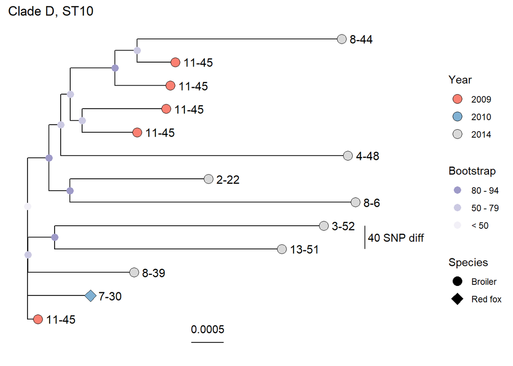

```r
annotate_tree(
  clean_trees$`Clade D`,
  tree_metadata,
  layout = "rectangular",
  tree_type = "treedata",
  line_width = 0.5,
  label_variable = "Location",
  color_variable = "Year",
  shape_variable = "Species",
  bootstrap_var = "Bootstrap",
  clade_label_node = 24,
  clade_label = "40 SNP diff",
  cladelabel_offset = 0.00055,
  bootstrap_lab = FALSE,
  bootlab_size = 2,
  tippoint_size = 4,
  label_offset = 0.0001,
  shape_palette = palette_shape,
  color_palette = palette_color,
  node_palette = boot_palette
) +
  xlim(0, 0.006) +
  ggtitle("Clade D, ST10") +
  scale_color_manual(values = boot_palette,
                     breaks = c(">= 95",
                                "80 - 94",
                                "50 - 79",
                                "< 50"))
```

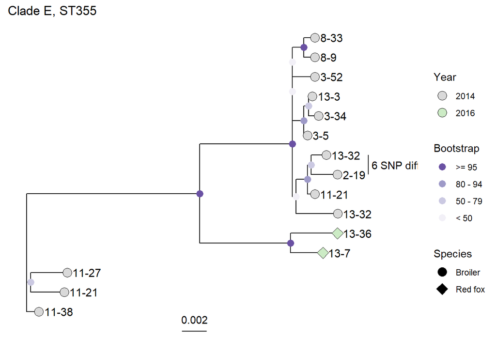

```r
annotate_tree(
  clean_trees$`Clade E`,
  tree_metadata,
  layout = "rectangular",
  tree_type = "treedata",
  line_width = 0.5,
  label_variable = "Location",
  color_variable = "Year",
  shape_variable = "Species",
  bootstrap_var = "Bootstrap",
  clade_label_node = 26,
  clade_label = "6 SNP diff",
  cladelabel_offset = 0.002,
  bootstrap_lab = FALSE,
  tippoint_size = 4,
  label_offset = 0.0003,
  shape_palette = palette_shape,
  color_palette = palette_color,
  node_palette = boot_palette
) +
  xlim(0, 0.03) +
  ggtitle("Clade E, ST355") +
  scale_color_manual(values = boot_palette,
                       breaks = c(">= 95",
                                  "80 - 94",
                                  "50 - 79",
                                  "< 50"))
```

# 4 P-value calculations on SNP distances within animal species

The table presents the non-exact p-values based on 1000 iterations of minimum SNP distances to the closest isolate within each animal species. The figure shows the distribution of the expected values with the observed values for each animal species denoted as an arrow. Red fox results is excluded from the plot as the observed distance values were too high to visualize.

```r
# Import distance data
total_dist <- read_delim("../data/snp_dists/final_Roary_gubbins_SNP_dists.tab",
                         delim = "\t") %>%
  rename("isol1" = `snp-dists 0.6.3`)

# Import isolate data
id_data <- read.table("../data/id.txt",
                      sep = "\t",
                      header = TRUE,
                      stringsAsFactors = F)

isolate_data <- read.table("../data/isolate_data.txt",
                           sep = "\t",
                           header = T,
                           stringsAsFactors = F)

# Set row/column values to unique species ID
row_id <- as.data.frame(total_dist$isol1) %>%
  rename("ref" = `total_dist$isol1`) %>%
  mutate(ref = sub("_pilon_spades.fasta", "", ref)) %>%
  left_join(id_data, by = "ref") %>%
  select(id) %>%
  left_join(isolate_data[,c("id", "species")], by = "id") %>%
  group_by(species) %>%
  mutate(n = 1:n(),
         isol1 = paste(species, n, sep = "_")) %>%
  ungroup() %>%
  select(isol1)

col_id <- as.data.frame(names(total_dist)) %>%
  rename("ref" = `names(total_dist)`) %>%
  mutate(ref = sub("_pilon_spades.fasta", "", ref)) %>%
  left_join(id_data, by = "ref") %>%
  select(id) %>%
  left_join(isolate_data[,c("id", "species")], by = "id") %>%
  group_by(species) %>%
  mutate(n = 1:n(),
         isol1 = paste(species, n, sep = "_")) %>%
  ungroup() %>%
  select(isol1) %>%
  mutate(isol1 = ifelse(isol1 == "NA_1", "isol1", isol1))

total_dist$isol1 <- row_id$isol1
names(total_dist) <- col_id$isol1

# Create data frame for iteration analysis
run_df <- total_dist %>%
  gather(isol2, value, -isol1) %>%
  filter(isol1 != isol2) %>%
  mutate(species1 = sub("_.+", "", isol1),
         species2 = sub("_.+", "", isol2)) %>%
  filter(species1 == species2) %>%
  group_by(isol2) %>%
  mutate(min_val = min(value)) %>%
  ungroup() %>%
  select(isol1, isol2, min_val, species1, species2) %>%
  rename("value" = min_val,
         "group1" = species1,
         "group2" = species2)

# Run iterations
df <- iterate(run_df, runs = 1000, method = "median")

# Filter out the observed values
segment_data <- filter(df, iter == 0,
                       group1 %in% c("Broiler", "Pig", "Wild bird"))

# Calculate non-exact p-values
df2 <- df %>%
  group_by(group1) %>%
  mutate(test = case_when(group1 == "Broiler" & metric <= 12 ~ 1,
                          group1 == "Wild bird" & metric <= 53 ~ 1,
                          group1 == "Pig" & metric <= 212 ~ 1,
                          group1 == "Red fox" & metric <= 1388.5 ~ 1,
                          TRUE ~ 0)) %>%
  split(f = .$group1)

lapply(df2, function(x) round(sum(x$test)/length(x$test), 3)) %>%
  bind_rows() %>%
  mutate(Iterations = 1000) %>%
  kable() %>%
  kable_styling(bootstrap_options = c("striped", "hover"))
```

| Broiler | Pig | Red fox | Wild bird | Iterations |
| --- | --- | --- | --- | --- |
| 0.001 | 1 | 1 | 1 | 1000 |

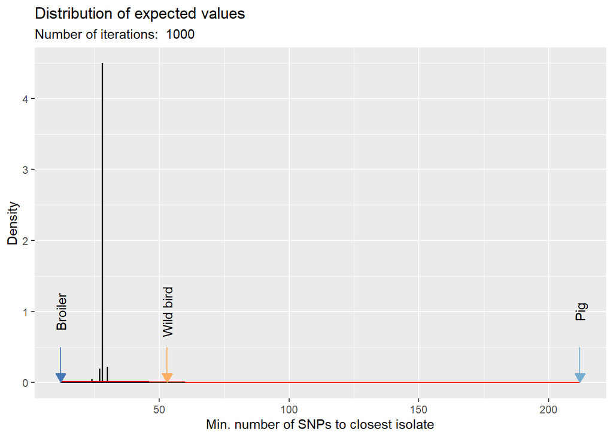

```r
# Plot results, exclude red fox (too high values for the plot to be visible)
plot_df <- df %>%
  filter(group1 %in% c("Broiler", "Pig", "Wild bird"))

ggplot(plot_df, aes(metric)) +
  geom_histogram(
    aes(y = ..density..),
    binwidth = 0.2,
    color = "black",
    fill = "grey80"
  ) +
  stat_function(fun = dnorm,
                args = with(df, c(
                  mean = mean(metric), sd = sd(metric)
                )),
                color = "red") +
  geom_segment(
    segment_data,
    mapping = aes(
      x = metric,
      xend = metric,
      y = 0.5,
      yend = 0,
      color = group1
    ),
    arrow = arrow(length = unit(0.3, "cm"),
                  type = "closed")
  ) +
  geom_text(segment_data,
            mapping = aes(label = group1,
                          x = metric),
            y = 1,
            angle = 90) +
  guides(color = FALSE) +
  labs(x = "Min. number of SNPs to closest isolate",
       y = "Density") +
  ggtitle(label = "Distribution of expected values",
          subtitle = paste("Number of iterations: ", max(df$iter))) +
  theme(plot.title = element_text(hjust = 0)) +
  scale_color_manual(values = palette)
```

# 5 NMDS Analysis of resistance mechanisms

Non-metric multidimensional scaling (NMDS) was used to see if the distribution of quinolone resistance mechanisms from some sequence types were more homogenous than in other sequence types.

```r
res_mechanisms <- read.table("../data/MDS_data.txt",
                       sep = "\t",
                       header = TRUE,
                       stringsAsFactors = FALSE) %>%
  column_to_rownames("id")

bin_dist <- dist(res_mechanisms,
                 method = "binary")

nmds_df <- metaMDS(bin_dist,
                   trymax = 200,
                   trace = FALSE) # silence the output

print(paste0("Stress: ", round(nmds_df$stress, 3)))
```

```
## [1] "Stress: 0.046"
```

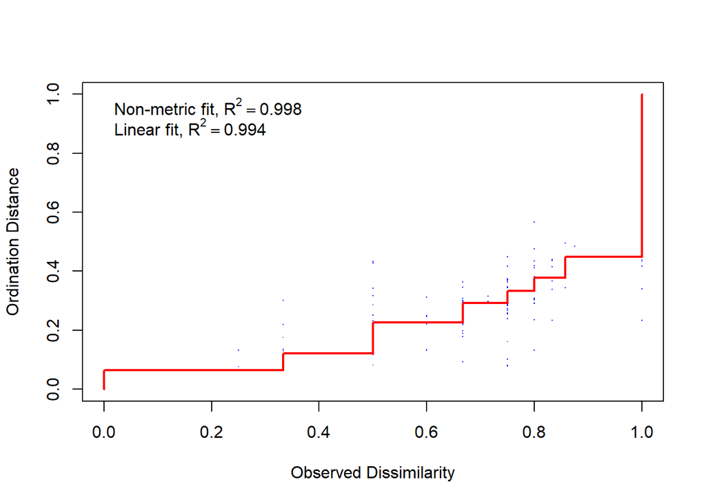

```r
stressplot(nmds_df)
```